# Reproducible Research: Peer Assessment 1

Sutha Kathiravan

7/8/2020

## Loading and preprocessing the data

1. Load the data (i.e. read.csv)

```r
setwd("~/Reproducible research")
activity<-read.csv("activity.csv")
```

2. Process/transform the data (if necessary) into a format suitable for your analysis

```r
dim(activity)
```

```
## [1] 17568     3
```

```r
names(activity)
```

```
## [1] "steps"    "date"     "interval"
```

```r
head(activity)
```

```
##   steps       date interval
## 1    NA 2012-10-01        0
## 2    NA 2012-10-01        5
## 3    NA 2012-10-01       10
## 4    NA 2012-10-01       15
## 5    NA 2012-10-01       20
## 6    NA 2012-10-01       25
```

```r
str(activity)
```

```
## 'data.frame':    17568 obs. of  3 variables:
##  $ steps   : int  NA NA NA NA NA NA NA NA NA NA ...
##  $ date    : chr  "2012-10-01" "2012-10-01" "2012-10-01" "2012-10-01" ...
##  $ interval: int  0 5 10 15 20 25 30 35 40 45 ...
```

Based on the information, we have 3 columns - steps,date and interval and we have 17568 rows. There are also some missing values. Let’s find the number of NA’s in the dataset.

```r
#total number of missing data
sum(is.na(activity$steps))
```

```
## [1] 2304
```

So, we have 2304 missing values. The date will be formatted as accordingly for further analysis.

```r
library(lubridate)
activity$date<-ymd(activity$date)
length(unique(activity$date))
```

```
## [1] 61
```

## What is mean total number of steps taken per day?

For this part of the assignment, you can ignore the missing values in the dataset.

1. Calculate the total number of steps taken per day

```r
library(ggplot2)
library(plyr)
totalsteps <- aggregate(activity$steps ~ activity$date, FUN=sum, )
colnames(totalsteps)<- c("Date", "Steps")
```

2. If you do not understand the difference between a histogram and a barplot, research the difference between them. Make a histogram of the total number of steps taken each day

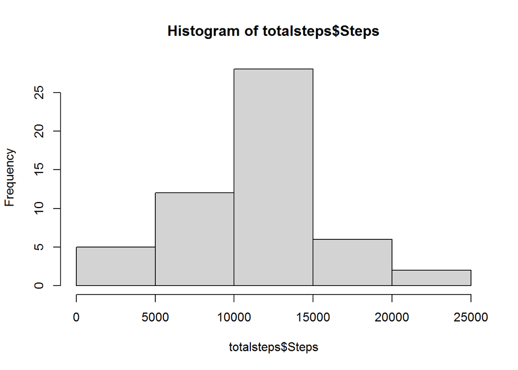

```r
hist(totalsteps$Steps)
```

3. Calculate and report the mean and median of the total number of steps taken per day.

```r
mean(totalsteps$Steps)
```

```
## [1] 10766.19
```

```r
median(totalsteps$Steps)
```

```
## [1] 10765
```